# NEET and mental health meta-analyses

Sofia Danna

25 May 2020

# Mise en place

- Code: the following tutorial will be used for analyses https://bookdown.org/MathiasHarrer/Doing_Meta_Analysis_in_R/
- Analysis: main analyses will use random effects models; subgroup analyses will be fixed effects models
- Data
  - neet2 is the updated dataset that Gen and I decided on on 18 October 2019. By only using observations where Repeated_measures=NA, there should no longer be any repeated samples pooled together. All variables should be accurately re-derived. This is the dataset Sofia saved after cleaning data in R.
  - neet3 is the same as neet2 but includes the information on age, to be used only for the age subgroup analysis
  - ON MAY 23 I want to use only neet3 and translate everything using dplyr

```r
# On Sofia's Douglas Windows computer
#neet2 <- read.csv("C:/Users/dansof/Dropbox/PEPP new/NEET meta-analysis/metaanalysis/neet2.csv")
#neet3 <- read.csv("C:/Users/dansof/Dropbox/PEPP new/NEET meta-analysis/metaanalysis/neet3.csv")

# On Sofia's personal Mac
neet <- read.csv("~/Dropbox/PEPP/NEET meta-analysis/metaanalysis/neet 20200525.csv")
```

checking out the variables in the updated NEET dataframe

```r
neet
```

| X | Study | Country | study_no | Mental.health.measures | Temporality.of.measures | Results | Repeated_sample | MH_measure | MH.measure.included | Gender | Age_at_interview | OR | LowerCI | UpperCI | OR_ln | lower_ln | upper_ln | SE | LowerCI_sens | UpperCI_sens | Distress | Mood | Anxiety | Behavioral | Alcohol | Cannabis | Drug | Suicidal | Any | … |
| --- | --- | --- | --- | --- | --- | --- | --- | --- | --- | --- | --- | --- | --- | --- | --- | --- | --- | --- | --- | --- | --- | --- | --- | --- | --- | --- | --- | --- | --- | --- |
| 2 | Baggio, 2015 | Switzerland | baggio 2015 1 | General mental health | MH-->NEET | OR 0.90, P<0.001 | NA | distress | NA | all | >=18 | 0.900 | 0.850 | 0.960 | -0.105360516 | -0.162518929 | -0.040821995 | 0.03104514 | NA | NA | 1 | 0 | 0 | 0 | 0 | 0 | 0 | 0 | 0 | … |
| 3 | Baggio, 2015 | Switzerland | baggio 2015 2 | Depressive symptoms | MH-->NEET | OR 1.11, P<0.001 | NA | depression | NA | all | >=18 | 1.110 | 1.040 | 1.180 | 0.104360015 | 0.039220713 | 0.165514438 | 0.03221779 | NA | NA | 0 | 1 | 0 | 0 | 0 | 0 | 0 | 0 | 0 | … |
| 4 | Baggio, 2015 | Switzerland | baggio 2015 3 | Binge drinking | MH-->NEET | OR NA, P>0.05 | NA | alcohol | NA | all | >=18 | NA | NA | NA | NA | NA | NA | NA | NA | NA | 0 | 0 | 0 | 0 | 1 | 0 | 0 | 0 | 0 | … |
| 5 | Baggio, 2015 | Switzerland | baggio 2015 4 | Cannabis use disorder | MH-->NEET | OR 1.09, P<0.001 | NA | cannabis | NA | all | >=18 | 1.090 | 1.040 | 1.150 | 0.086177696 | 0.039220713 | 0.139761942 | 0.02564827 | NA | NA | 0 | 0 | 0 | 0 | 0 | 1 | 0 | 0 | 0 | … |
| 7 | Bania, 2019 | Norway | bania 2019 1 | Emotional problems | MH-->NEET | calculated | NA | distress | NA | all | <18 | 0.971 | 0.918 | 1.023 | -0.029428811 | -0.085557888 | 0.022739487 | 0.02762688 | NA | NA | 1 | 0 | 0 | 0 | 0 | 0 | 0 | 0 | 0 | … |
| 8 | Bania, 2019 | Norway | bania 2019 2 | Emotional problems | MH-->NEET | Males: OR 0.88, 95% CI 0.81, 0.97 | NA | distress | NA | boy | NA | 0.880 | 0.810 | 0.970 | -0.127833371 | -0.210721031 | -0.030459207 | 0.04598516 | NA | NA | 1 | 0 | 0 | 0 | 0 | 0 | 0 | 0 | 0 | … |
| 9 | Bania, 2019 | Norway | bania 2019 3 | Emotional problems | MH-->NEET | Females: OR 1.04, 95% CI 0.97, 1.11 | NA | distress | NA | girl | NA | 1.040 | 0.970 | 1.110 | 0.039220713 | -0.030459207 | 0.104360015 | 0.03439266 | NA | NA | 1 | 0 | 0 | 0 | 0 | 0 | 0 | 0 | 0 | … |
| 10 | Bania, 2019 | Norway | bania 2019 4 | Conduct problems | MH-->NEET | calculated | NA | behavioral | NA | all | <18 | 1.221 | 1.157 | 1.284 | 0.199670195 | 0.145830448 | 0.249980205 | 0.02656882 | NA | NA | 0 | 0 | 0 | 1 | 0 | 0 | 0 | 0 | 0 | … |
| 11 | Bania, 2019 | Norway | bania 2019 5 | Conduct problems | MH-->NEET | Males: OR 1.17, 95% CI 1.07, 1.28 | NA | behavioral | NA | boy | NA | 1.170 | 1.070 | 1.280 | 0.157003749 | 0.067658649 | 0.246860078 | 0.04571465 | NA | NA | 0 | 0 | 0 | 1 | 0 | 0 | 0 | 0 | 0 | … |
| 12 | Bania, 2019 | Norway | bania 2019 6 | Conduct problems | MH-->NEET | Females: OR 1.25, 95% CI 1.17, 1.33 | NA | behavioral | NA | girl | NA | 1.250 | 1.170 | 1.330 | 0.223143551 | 0.157003749 | 0.285178942 | 0.03269775 | NA | NA | 0 | 0 | 0 | 1 | 0 | 0 | 0 | 0 | 0 | … |

[output cut: 100 more lines]

```r
str(neet)
```

```
## 'data.frame':    110 obs. of  32 variables:
##  $ X                      : int  2 3 4 5 7 8 9 10 11 12 ...
##  $ Study                  : Factor w/ 20 levels "Baggio, 2015",..: 1 1 1 1 2 2 2 2 2 2 ...
##  $ Country                : Factor w/ 10 levels "Australia","Brazil",..: 9 9 9 9 7 7 7 7 7 7 ...
##  $ study_no               : Factor w/ 110 levels "baggio 2015 1",..: 1 2 3 4 5 6 7 8 9 10 ...
##  $ Mental.health.measures : Factor w/ 47 levels "Alcohol dependence",..: 33 26 13 18 31 31 31 22 22 22 ...
##  $ Temporality.of.measures: Factor w/ 3 levels "MH-->NEET","MH<-->NEET",..: 1 1 1 1 1 1 1 1 1 1 ...
##  $ Results                : Factor w/ 98 levels "Age<18: OR 0.95, 95% CI 0.72, 1.26",..: 42 49 95 46 14 27 17 14 31 19 ...
##  $ Repeated_sample        : int  NA NA NA NA NA NA NA NA NA NA ...
##  $ MH_measure             : Factor w/ 9 levels "alcohol","anxiety",..: 7 6 1 5 7 7 7 4 4 4 ...
##  $ MH.measure.included    : logi  NA NA NA NA NA NA ...
##  $ Gender                 : Factor w/ 3 levels "all","boy","girl": 1 1 1 1 1 2 3 1 2 3 ...
##  $ Age_at_interview       : Factor w/ 2 levels "<18",">=18": 2 2 2 2 1 NA NA 1 NA NA ...
##  $ OR                     : num  0.9 1.11 NA 1.09 0.971 ...
##  $ LowerCI                : num  0.85 1.04 NA 1.04 0.918 ...
```

[output cut: 18 more lines]

```r
#rederiving ln of OR and CI limits
neet <- read.csv("~/Dropbox/PEPP/NEET meta-analysis/metaanalysis/neet 20200525.csv")
View(neet)

#re-deriving OR and limits
neet$OR_ln <- log(neet$OR)
neet$lower_ln <- log(neet$LowerCI)
neet$upper_ln <- log(neet$UpperCI)

#re-deriving SE [ (upper_ln - lower_ln) / 3.92 ]
neet$SE <- ((neet$upper_ln-neet$lower_ln)/3.92)

View(neet)

write.csv(neet,'neet 20200525.csv')
```

installing and loading meta package

```r
install.packages("meta", repos = "http://cran.us.r-project.org")
install.packages("dplyr", repos = "http://cran.us.r-project.org")
library(meta)
library(metafor)
library(dplyr)
```

| Parameter | Function |
| --- | --- |
| TE | This tells R to use the TE column to retrieve the effect sizes for each study |
| seTE | This tells R to use the seTE column to retrieve the standard error for each study |
| data= | After =, paste the name of your dataset here |
| studlab=paste() | This tells the function were the labels for each study are stored. If you named the spreadsheet columns as advised, this should be studlab=paste(Author) |
| comb.fixed= | Whether to use a fixed-effects-model |
| comb.random= | Whether to use a random-effects-model. This has to be set to TRUE |
| method.tau= | Which estimator to use for the between-study variance |
| hakn= | Whether to use the Knapp-Hartung method |
| prediction= | Whether to print a prediction interval for the effect of future studies based on present evidence |
| sm= | The summary measure we want to calculate. We can either calculate the mean difference (MD) or Hedges’ g (SMD) |

Using the instructions from the tutorial by Mathias Harrer (url above),

| instead of | we will use |
| --- | --- |
| “Author” | “Study” |
| “TE” | “OR_ln” |
| “seTE” | “SE” |

# Analyses: Mental health measure

## DISTRESS

```r
MHdis.Gall.rep0 <- filter(neet, Distress==1 & is.na(Repeated_sample)==TRUE & is.na(rep_dis)==TRUE)


MHdis.Gall.rep0
```

| X | Study | Country | study_no | Mental.health.measures | Temporality.of.measures | Results | Repeated_sample | MH_measure | MH.measure.included | Gender | Age_at_interview | OR | LowerCI | UpperCI | OR_ln | lower_ln | upper_ln | SE | LowerCI_sens | UpperCI_sens | Distress | Mood | Anxiety | Behavioral | Alcohol | Cannabis | Drug | Suicidal | Any | … |
| --- | --- | --- | --- | --- | --- | --- | --- | --- | --- | --- | --- | --- | --- | --- | --- | --- | --- | --- | --- | --- | --- | --- | --- | --- | --- | --- | --- | --- | --- | --- |
| 2 | Baggio, 2015 | Switzerland | baggio 2015 1 | General mental health | MH-->NEET | OR 0.90, P<0.001 | NA | distress | NA | all | >=18 | 0.900 | 0.850 | 0.960 | -0.10536052 | -0.16251893 | -0.040821995 | 0.03104514 | NA | NA | 1 | 0 | 0 | 0 | 0 | 0 | 0 | 0 | 0 | … |
| 7 | Bania, 2019 | Norway | bania 2019 1 | Emotional problems | MH-->NEET | calculated | NA | distress | NA | all | <18 | 0.971 | 0.918 | 1.023 | -0.02942881 | -0.08555789 | 0.022739487 | 0.02762688 | NA | NA | 1 | 0 | 0 | 0 | 0 | 0 | 0 | 0 | 0 | … |
| 14 | Basta, 2019 | Greece | basta 2019 1 | Psychological distress | MHNEET | All: OR 0.98, 95% CI 0.96, 1.01 | NA | distress | NA | all | NA | 0.980 | 0.960 | 1.010 | -0.02020271 | -0.04082199 | 0.009950331 | 0.01295212 | NA | NA | 1 | 0 | 0 | 0 | 0 | 0 | 0 | 0 | 0 | … |
| 32 | Bynner, 2002 | UK | bynner 2002 1 | Psychological distress | NEET-->MH | calculated | NA | distress | NA | all | <18 | 1.783 | 0.762 | 2.805 | 0.57829734 | -0.27180872 | 1.031403539 | 0.33245211 | NA | NA | 1 | 0 | 0 | 0 | 0 | 0 | 0 | 0 | 0 | … |
| 74 | Hale, 2018 | UK | hale 2018 1 | Psychological distress | MH-->NEET | calculated | NA | distress | NA | all | >=18 | 1.573 | 1.221 | 1.925 | 0.45298462 | 0.19967020 | 0.654925968 | 0.11613668 | NA | NA | 1 | 0 | 0 | 0 | 0 | 0 | 0 | 0 | 0 | … |
| 78 | Henderson, 2017 | Canada | henderson 2017 1 | Internalizing disorders | MHNEET | Total: OR 1.15, 95% CI 0.95, 1.38 | NA | distress | NA | all | NA | 1.150 | 0.950 | 1.380 | 0.13976194 | -0.05129329 | 0.322083499 | 0.09524918 | NA | NA | 1 | 0 | 0 | 0 | 0 | 0 | 0 | 0 | 0 | … |
| 125 | Stea, 2019a | Sweden | Stea 2019a 1 | Psychological distress | MHNEET | Boys: OR NA, p>0.05 | NA | distress | NA | boy | NA | NA | NA | NA | NA | NA | NA | NA | NA | NA | 1 | 0 | 0 | 0 | 0 | 0 | 0 | 0 | 0 | … |
| 126 | Stea, 2019a | Sweden | Stea 2019a 2 | Psychological distress | MHNEET | Girls: OR 2.40, 95% CI 1.00, 5.20 | NA | distress | NA | girl | NA | 2.400 | 1.000 | 5.200 | 0.87546874 | 0.00000000 | 1.648658626 | 0.42057618 | NA | NA | 1 | 0 | 0 | 0 | 0 | 0 | 0 | 0 | 0 | … |

```r
meta.MHdis.Gall.rep0 <- metagen(OR_ln,
                     SE,
                     data=MHdis.Gall.rep0,
                     studlab=paste(Study),
                     comb.fixed = FALSE,
                     comb.random = TRUE,
                     method.tau = "DL",
                     hakn = FALSE,
                     prediction=FALSE,
                     sm="OR")
meta.MHdis.Gall.rep0
```

```
##                     OR           95%-CI %W(random)
## Baggio, 2015    0.9000 [0.8469; 0.9565]       24.1
## Bania, 2019     0.9710 [0.9198; 1.0250]       24.8
## Basta, 2019     0.9800 [0.9554; 1.0052]       26.8
## Bynner, 2002    1.7830 [0.9293; 3.4209]        1.7
## Hale, 2018      1.5730 [1.2528; 1.9751]        9.5
## Henderson, 2017 1.1500 [0.9542; 1.3860]       12.1
## Stea, 2019a         NA                         0.0
## Stea, 2019a     2.4000 [1.0525; 5.4728]        1.1
##
## Number of studies combined: k = 7
##
##                          OR           95%-CI    z p-value
## Random effects model 1.0416 [0.9550; 1.1361] 0.92  0.3571
##
## Quantifying heterogeneity:
##  tau^2 = 0.0072 [0.0088; 0.2940]; tau = 0.0847 [0.0937; 0.5422];
##  I^2 = 82.7% [65.6%; 91.3%]; H = 2.40 [1.71; 3.39]
##
## Test of heterogeneity:
##      Q d.f.  p-value
##  34.67    6 < 0.0001
##
## Details on meta-analytical method:
## - Inverse variance method
## - DerSimonian-Laird estimator for tau^2
## - Jackson method for confidence interval of tau^2 and tau
```

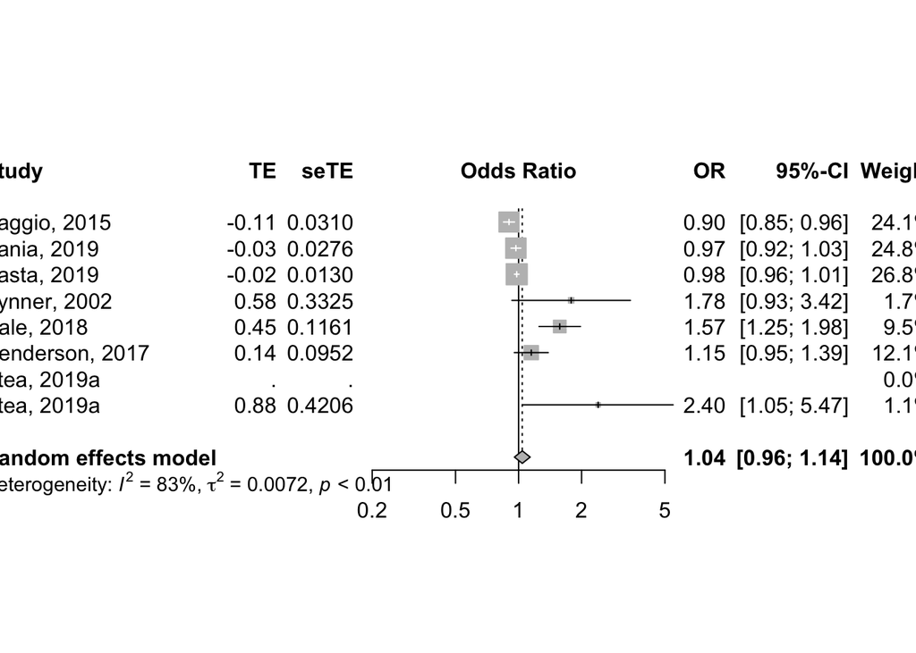

```r
forest(meta.MHdis.Gall.rep0)
```

### DISTRESS - directionality

# `{r} # # MHdis.Gall.rep1 <- neet2[which(neet2$Distress==1 & neet2$Gender=="all"),] # # MHdis.Gall.rep1 # # # meta.MHdis.Gall.rep1 <- metagen(OR_ln, # SE, # data=MHdis.Gall.rep1, # studlab=paste(Study), # comb.fixed = FALSE, # comb.random = TRUE, # method.tau = "DL", # hakn = FALSE, # prediction=FALSE, # sm="OR") # meta.MHdis.Gall.rep1 # # meta.MHdis.Gall.rep1.dir<-update.meta(meta.MHdis.Gall.rep1, # byvar=Temporality.of.measures, # comb.random = F, # comb.fixed = T) # meta.MHdis.Gall.rep1.dir # # # forest(meta.MHdis.Gall.rep1.dir) #`

### DISTRESS - age

# `{r} # # # MHdis.Gall.rep1.age <- neet3[which(neet3$Distress==1 & neet3$Gender=="all"),] # MHdis.Gall.rep1.age <- filter(neet3, Distress==1 & Gender=="all") # # # MHdis.Gall.rep1.age # # # meta.MHdis.Gall.rep1.age <- metagen(OR_ln, # SE, # data=MHdis.Gall.rep1.age, # studlab=paste(Study), # comb.fixed = FALSE, # comb.random = TRUE, # method.tau = "DL", # hakn = FALSE, # prediction=FALSE, # sm="OR") # meta.MHdis.Gall.rep1.age # # meta.MHdis.Gall.rep1.age.dir<-update.meta(meta.MHdis.Gall.rep1.age, # byvar=Age_at_interview, # comb.random = F, # comb.fixed = T) # meta.MHdis.Gall.rep1.age.dir # # # forest(meta.MHdis.Gall.rep1.age.dir) #`

### DISTRESS - gender

```r
MHdis.Gbg.rep0 <- filter(neet, Distress==1 & Gender!="all" & is.na(Repeated_sample))

MHdis.Gbg.rep0
```

| X | Study | Country | study_no | Mental.health.measures | Temporality.of.measures | Results | Repeated_sample | MH_measure | MH.measure.included | Gender | Age_at_interview | OR | LowerCI | UpperCI | OR_ln | lower_ln | upper_ln | SE | LowerCI_sens | UpperCI_sens | Distress | Mood | Anxiety | Behavioral | Alcohol | Cannabis | Drug | Suicidal | Any | … |
| --- | --- | --- | --- | --- | --- | --- | --- | --- | --- | --- | --- | --- | --- | --- | --- | --- | --- | --- | --- | --- | --- | --- | --- | --- | --- | --- | --- | --- | --- | --- |
| 8 | Bania, 2019 | Norway | bania 2019 2 | Emotional problems | MH-->NEET | Males: OR 0.88, 95% CI 0.81, 0.97 | NA | distress | NA | boy | NA | 0.88 | 0.81 | 0.97 | -0.12783337 | -0.21072103 | -0.03045921 | 0.04598516 | NA | NA | 1 | 0 | 0 | 0 | 0 | 0 | 0 | 0 | 0 | … |
| 9 | Bania, 2019 | Norway | bania 2019 3 | Emotional problems | MH-->NEET | Females: OR 1.04, 95% CI 0.97, 1.11 | NA | distress | NA | girl | NA | 1.04 | 0.97 | 1.11 | 0.03922071 | -0.03045921 | 0.10436002 | 0.03439266 | NA | NA | 1 | 0 | 0 | 0 | 0 | 0 | 0 | 0 | 0 | … |
| 15 | Basta, 2019 | Greece | basta 2019 2 | Psychological distress | MHNEET | Males: OR 0.99, 95% CI 0.96, 1.03 | NA | distress | NA | boy | NA | 0.99 | 0.96 | 1.03 | -0.01005034 | -0.04082199 | 0.02955880 | 0.01795428 | NA | NA | 1 | 0 | 0 | 0 | 0 | 0 | 0 | 0 | 0 | … |
| 16 | Basta, 2019 | Greece | basta 2019 3 | Psychological distress | MHNEET | Females: OR 0.98, 95% CI 0.95, 1.02 | NA | distress | NA | girl | NA | 0.98 | 0.95 | 1.02 | -0.02020271 | -0.05129329 | 0.01980263 | 0.01813671 | NA | NA | 1 | 0 | 0 | 0 | 0 | 0 | 0 | 0 | 0 | … |
| 33 | Bynner, 2002 | UK | bynner 2002 2 | Psychological distress | NEET-->MH | Males: OR 2.20, P>0.05 | NA | distress | NA | boy | NA | 2.20 | 0.86 | 5.63 | 0.78845736 | -0.15082289 | 1.72810944 | 0.47931947 | 1 | 4.85 | 1 | 0 | 0 | 0 | 0 | 0 | 0 | 0 | 0 | … |
| 34 | Bynner, 2002 | UK | bynner 2002 3 | Psychological distress | NEET-->MH | Females: OR 1.69, P>0.05 | NA | distress | NA | girl | NA | 1.69 | 0.90 | 3.16 | 0.52472853 | -0.10536052 | 1.15057203 | 0.32039095 | 1 | 2.86 | 1 | 0 | 0 | 0 | 0 | 0 | 0 | 0 | 0 | … |
| 75 | Hale, 2018 | UK | hale 2018 2 | Psychological distress | MH-->NEET | Males: OR 1.72, 95% CI 1.24, 2.41 | NA | distress | NA | boy | NA | 1.72 | 1.24 | 2.41 | 0.54232429 | 0.21511138 | 0.87962675 | 0.16951923 | NA | NA | 1 | 0 | 0 | 0 | 0 | 0 | 0 | 0 | 0 | … |
| 76 | Hale, 2018 | UK | hale 2018 3 | Psychological distress | MH-->NEET | Females: OR 1.49, 95% CI 1.11, 1.99 | NA | distress | NA | girl | NA | 1.49 | 1.11 | 1.99 | 0.39877612 | 0.10436002 | 0.68813464 | 0.14892210 | NA | NA | 1 | 0 | 0 | 0 | 0 | 0 | 0 | 0 | 0 | … |
| 81 | Henderson, 2017 | Canada | henderson 2017 4 | Internalizing disorders | MHNEET | Boys: OR 1.39, 95% CI 1.08, 1.78 | NA | distress | NA | boy | NA | 1.39 | 1.08 | 1.78 | 0.32930375 | 0.07696104 | 0.57661336 | 0.12746233 | NA | NA | 1 | 0 | 0 | 0 | 0 | 0 | 0 | 0 | 0 | … |
| 82 | Henderson, 2017 | Canada | henderson 2017 5 | Internalizing disorders | MHNEET | Girls: OR 1.08, 95% CI 0.80, 1.45 | NA | distress | NA | girl | NA | 1.08 | 0.80 | 1.45 | 0.07696104 | -0.22314355 | 0.37156356 | 0.15171100 | NA | NA | 1 | 0 | 0 | 0 | 0 | 0 | 0 | 0 | 0 | … |

[output cut: 2 more lines]

```r
meta.MHdis.Gbg.rep0 <- metagen(OR_ln,
                                SE,
                                data=MHdis.Gbg.rep0,
                                studlab=paste(Study),
                                comb.fixed = FALSE,
                                comb.random = TRUE,
                                method.tau = "DL",
                                hakn = FALSE,
                                prediction=FALSE,
                                sm="OR")
meta.MHdis.Gbg.rep0
```

```
##                     OR           95%-CI %W(random)
## Bania, 2019     0.8800 [0.8042; 0.9630]       16.6
## Bania, 2019     1.0400 [0.9722; 1.1125]       18.5
## Basta, 2019     0.9900 [0.9558; 1.0255]       20.8
## Basta, 2019     0.9800 [0.9458; 1.0155]       20.8
## Bynner, 2002    2.2000 [0.8599; 5.6289]        0.6
## Bynner, 2002    1.6900 [0.9019; 3.1667]        1.3
## Hale, 2018      1.7200 [1.2338; 2.3979]        4.1
## Hale, 2018      1.4900 [1.1128; 1.9950]        5.1
## Henderson, 2017 1.3900 [1.0827; 1.7845]        6.4
## Henderson, 2017 1.0800 [0.8022; 1.4540]        4.9
## Stea, 2019a         NA                         0.0
## Stea, 2019a     2.4000 [1.0525; 5.4728]        0.8
##
## Number of studies combined: k = 11
##
##                          OR           95%-CI    z p-value
## Random effects model 1.0687 [0.9913; 1.1522] 1.73  0.0834
##
## Quantifying heterogeneity:
##  tau^2 = 0.0068 [0.0103; 0.1868]; tau = 0.0822 [0.1014; 0.4322];
##  I^2 = 77.5% [59.9%; 87.3%]; H = 2.11 [1.58; 2.81]
##
## Test of heterogeneity:
##      Q d.f.  p-value
##  44.37   10 < 0.0001
##
## Details on meta-analytical method:
## - Inverse variance method
## - DerSimonian-Laird estimator for tau^2
## - Jackson method for confidence interval of tau^2 and tau
```

```r
meta.MHdis.Gbg.rep0<-update.meta(meta.MHdis.Gbg.rep0,
                                      byvar=Gender,
                                      comb.random = F,
                                      comb.fixed = T)
meta.MHdis.Gbg.rep0
```

```
##                     OR           95%-CI %W(fixed) Gender
## Bania, 2019     0.8800 [0.8042; 0.9630]       6.2    boy
## Bania, 2019     1.0400 [0.9722; 1.1125]      11.0   girl
## Basta, 2019     0.9900 [0.9558; 1.0255]      40.5    boy
## Basta, 2019     0.9800 [0.9458; 1.0155]      39.7   girl
## Bynner, 2002    2.2000 [0.8599; 5.6289]       0.1    boy
## Bynner, 2002    1.6900 [0.9019; 3.1667]       0.1   girl
## Hale, 2018      1.7200 [1.2338; 2.3979]       0.5    boy
## Hale, 2018      1.4900 [1.1128; 1.9950]       0.6   girl
## Henderson, 2017 1.3900 [1.0827; 1.7845]       0.8    boy
## Henderson, 2017 1.0800 [0.8022; 1.4540]       0.6   girl
## Stea, 2019a         NA                        0.0    boy
## Stea, 2019a     2.4000 [1.0525; 5.4728]       0.1   girl
##
## Number of studies combined: k = 11
##
##                        OR           95%-CI     z p-value
## Fixed effect model 0.9940 [0.9720; 1.0165] -0.52  0.5999
##
## Quantifying heterogeneity:
##  tau^2 = 0.0068 [0.0103; 0.1868]; tau = 0.0822 [0.1014; 0.4322];
##  I^2 = 77.5% [59.9%; 87.3%]; H = 2.11 [1.58; 2.81]
##
## Quantifying residual heterogeneity:
##  I^2 = 79.5% [63.0%; 88.7%]; H = 2.21 [1.64; 2.97]
##
## Test of heterogeneity:
##      Q d.f.  p-value
##  44.37   10 < 0.0001
##
## Results for subgroups (fixed effect model):
##                 k     OR           95%-CI     Q   I^2  tau^2    tau
## Gender = boy    5 0.9867 [0.9554; 1.0192] 27.00 85.2% 0.0231 0.1520
## Gender = girl   6 1.0008 [0.9702; 1.0323] 16.98 70.6% 0.0080 0.0896
##
## Test for subgroup differences (fixed effect model):
##                    Q d.f.  p-value
## Between groups  0.38    1   0.5366
## Within groups  43.98    9 < 0.0001
##
## Details on meta-analytical method:
## - Inverse variance method
## - DerSimonian-Laird estimator for tau^2
## - Jackson method for confidence interval of tau^2 and tau
```

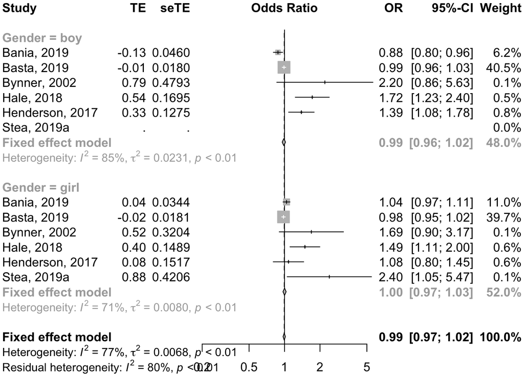

```r
forest(meta.MHdis.Gbg.rep0)
```

## MOOD

mood = 1, gender = all, repeated sample = 0

```r
MHmood.Gall.rep0 <- filter(neet, Mood==1 & Gender=="all" & is.na(Repeated_sample))

MHmood.Gall.rep0
```

| X | Study | Country | study_no | Mental.health.measures | Temporality.of.measures | Results | Repeated_sample | MH_measure | MH.measure.included | Gender | Age_at_interview | OR | LowerCI | UpperCI | OR_ln | lower_ln | upper_ln | SE | LowerCI_sens | UpperCI_sens | Distress | Mood | Anxiety | Behavioral | Alcohol | Cannabis | Drug | Suicidal | Any | … |
| --- | --- | --- | --- | --- | --- | --- | --- | --- | --- | --- | --- | --- | --- | --- | --- | --- | --- | --- | --- | --- | --- | --- | --- | --- | --- | --- | --- | --- | --- | --- |
| 3 | Baggio, 2015 | Switzerland | baggio 2015 2 | Depressive symptoms | MH-->NEET | OR 1.11, P<0.001 | NA | depression | NA | all | >=18 | 1.11 | 1.04 | 1.18 | 0.10436002 | 0.03922071 | 0.1655144 | 0.03221779 | NA | NA | 0 | 1 | 0 | 0 | 0 | 0 | 0 | 0 | 0 | … |
| 24 | Benjet, 2012 | Mexico | benjet 2012 1 | Mood disorder | MHNEET | OR 2.7, 95% CI 1.8, 4.2 | NA | depression | NA | all | <18 | 2.70 | 1.80 | 4.20 | 0.99325177 | 0.58778666 | 1.4350845 | 0.21614741 | NA | NA | 0 | 1 | 0 | 0 | 0 | 0 | 0 | 0 | 0 | … |
| 36 | Gariepy, 2018 | Canada | gariepy 2018 1 | Depressive disorder | MHNEET | OR 1.7, 95% CI 1.1, 2.6 | NA | depression | NA | all | NA | 1.70 | 1.10 | 2.60 | 0.53062825 | 0.09531018 | 0.9555114 | 0.21943910 | NA | NA | 0 | 1 | 0 | 0 | 0 | 0 | 0 | 0 | 0 | … |
| 44 | Goldman-Mellor, 2016 | UK | goldman 2016 1 | Depressive disorder | MHNEET | OR 1.68, 95% CI 1.33, 2.13 | NA | depression | NA | all | >=18 | 1.68 | 1.33 | 2.13 | 0.51879379 | 0.28517894 | 0.7561220 | 0.12013853 | NA | NA | 0 | 1 | 0 | 0 | 0 | 0 | 0 | 0 | 0 | … |
| 100 | O'Dea, 2014 | Australia | odea 2014 1 | Mood disorder | MHNEET | OR 1.10, 95% CI 1.05,1.15 | NA | depression | NA | all | NA | 1.10 | 1.05 | 1.15 | 0.09531018 | 0.04879016 | 0.1397619 | 0.02320709 | NA | NA | 0 | 1 | 0 | 0 | 0 | 0 | 0 | 0 | 0 | … |
| 105 | Power, 2015 | Ireland | power 2015 1 | Depressive disorder (lifetime) | MHNEET | OR NA, P>0.05 | NA | depression | NA | all | >=18 | NA | NA | NA | NA | NA | NA | NA | NA | NA | 0 | 1 | 0 | 0 | 0 | 0 | 0 | 0 | 0 | … |
| 123 | Lopez-Lopez, 2019 | UK | Lopez 2019 1 | Depressive symptoms | MH-->NEET | OR 5.17, 95% CI 1.95, 13.70 | NA | depression | NA | all | NA | 5.17 | 1.95 | 13.70 | 1.64287269 | 0.66782937 | 2.6173958 | 0.49733838 | NA | NA | 0 | 1 | 0 | 0 | 0 | 0 | 0 | 0 | 0 | … |

```r
meta.MHmood.Gall.rep0 <- metagen(OR_ln,
                                SE,
                                data=MHmood.Gall.rep0,
                                studlab=paste(Study),
                                comb.fixed = FALSE,
                                comb.random = TRUE,
                                method.tau = "DL",
                                hakn = FALSE,
                                prediction=FALSE,
                                sm="OR")
meta.MHmood.Gall.rep0
```

```
##                          OR            95%-CI %W(random)
## Baggio, 2015         1.1100 [1.0421;  1.1824]       28.5
## Benjet, 2012         2.7000 [1.7676;  4.1243]       10.4
## Gariepy, 2018        1.7000 [1.1058;  2.6136]       10.2
## Goldman-Mellor, 2016 1.6800 [1.3275;  2.1260]       18.9
## O'Dea, 2014          1.1000 [1.0511;  1.1512]       29.1
## Power, 2015              NA                          0.0
## Lopez-Lopez, 2019    5.1700 [1.9505; 13.7033]        2.8
##
## Number of studies combined: k = 6
##
##                          OR           95%-CI    z  p-value
## Random effects model 1.4322 [1.2082; 1.6977] 4.14 < 0.0001
##
## Quantifying heterogeneity:
##  tau^2 = 0.0254 [0.0345; 1.2655]; tau = 0.1592 [0.1858; 1.1250];
##  I^2 = 88.0% [76.3%; 93.9%]; H = 2.88 [2.05; 4.05]
##
## Test of heterogeneity:
##      Q d.f.  p-value
##  41.59    5 < 0.0001
##
## Details on meta-analytical method:
## - Inverse variance method
## - DerSimonian-Laird estimator for tau^2
## - Jackson method for confidence interval of tau^2 and tau
```

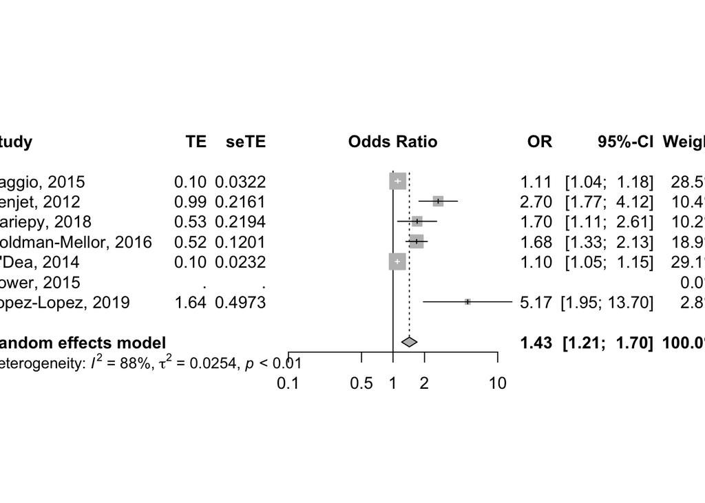

```r
forest(meta.MHmood.Gall.rep0)
```

### MOOD - directionality

# `{r} # MHmood.Gall.rep1 <- neet2[which(neet2$Mood==1 & neet2$Gender=="all"),] # # MHmood.Gall.rep1 # # # meta.MHmood.Gall.rep1 <- metagen(OR_ln, # SE, # data=MHmood.Gall.rep1, # studlab=paste(Study), # comb.fixed = FALSE, # comb.random = TRUE, # method.tau = "DL", # hakn = FALSE, # prediction=FALSE, # sm="OR") # meta.MHmood.Gall.rep1 # # meta.MHmood.Gall.rep1.dir<-update.meta(meta.MHmood.Gall.rep1, # byvar=Temporality.of.measures, # comb.random = F, # comb.fixed = T) # meta.MHmood.Gall.rep1.dir # # forest(meta.MHmood.Gall.rep1.dir) #`

### MOOD - age

# `{r} # # MHmood.Gall.rep0.age <- neet3[which(neet3$Mood==1 & neet3$Gender=="all" & is.na(neet3$Repeated_sample)),] # # MHmood.Gall.rep0.age # # MHmood.Gall.rep0.age <- bind_rows(MHmood.Gall.rep0.age, neet3[which(neet3$study_no=="gutierrez 2019 1"),]) # # MHmood.Gall.rep0.age # # # meta.MHmood.Gall.rep0.age <- metagen(OR_ln, # SE, # data=MHmood.Gall.rep0.age, # studlab=paste(Study), # comb.fixed = FALSE, # comb.random = TRUE, # method.tau = "DL", # hakn = FALSE, # prediction=FALSE, # sm="OR") # meta.MHmood.Gall.rep0.age # # meta.MHmood.Gall.rep0.age.dir<-update.meta(meta.MHmood.Gall.rep0.age, # byvar=Age_at_interview, # comb.random = F, # comb.fixed = T) # meta.MHmood.Gall.rep0.age.dir # # # forest(meta.MHmood.Gall.rep0.age.dir) #`

### MOOD - gender

# `{r} # MHmood.Gbg.rep0 <- neet2[which(neet2$Mood==1 & neet2$Gender!="all" & is.na(neet2$Repeated_sample)),] # # head(MHmood.Gbg.rep0) #`

## ANXIETY

anxiety = 1, gender = all, repeated sample = 0

# `{r} # MHanx.Gall.rep0 <- neet2[which(neet2$Anxiety==1 & neet2$Gender=="all" & is.na(neet2$Repeated_sample)),] # # head(MHanx.Gall.rep0) # # meta.MHanx.Gall.rep0 <- metagen(OR_ln, # SE, # data=MHanx.Gall.rep0, # studlab=paste(Study), # comb.fixed = FALSE, # comb.random = TRUE, # method.tau = "DL", # hakn = FALSE, # prediction=FALSE, # sm="OR") # meta.MHanx.Gall.rep0 #`

### ANXIETY - directionality

# `{r} # MHanx.Gall.rep1 <- neet2[which(neet2$Anxiety==1 & neet2$Gender=="all"),] # # head(MHanx.Gall.rep1) # # meta.MHanx.Gall.rep1 <- metagen(OR_ln, # SE, # data=MHanx.Gall.rep1, # studlab=paste(Study), # comb.fixed = FALSE, # comb.random = TRUE, # method.tau = "DL", # hakn = FALSE, # prediction=FALSE, # sm="OR") # meta.MHanx.Gall.rep1 # meta.MHanx.Gall.rep1.dir<-update.meta(meta.MHanx.Gall.rep1, # byvar=Temporality.of.measures, # comb.random = F, # comb.fixed = T) # meta.MHanx.Gall.rep1.dir # # forest(meta.MHanx.Gall.rep1.dir) #`

### ANXIETY - age

# `{r} # # MHanx.Gall.rep0.age <- neet3[which(neet3$Anxiety==1 & neet3$Gender=="all" & is.na(neet3$Repeated_sample)),] # # MHanx.Gall.rep0.age # # MHanx.Gall.rep0.age <- bind_rows(MHanx.Gall.rep0.age, neet3[which(neet3$study_no=="gutierrez 2019 2"),]) # # MHanx.Gall.rep0.age # # # meta.MHanx.Gall.rep0.age <- metagen(OR_ln, # SE, # data=MHanx.Gall.rep0.age, # studlab=paste(Study), # comb.fixed = FALSE, # comb.random = TRUE, # method.tau = "DL", # hakn = FALSE, # prediction=FALSE, # sm="OR") # meta.MHanx.Gall.rep0.age # # meta.MHanx.Gall.rep0.age.dir<-update.meta(meta.MHanx.Gall.rep0.age, # byvar=Age_at_interview, # comb.random = F, # comb.fixed = T) # meta.MHanx.Gall.rep0.age.dir # # # forest(meta.MHanx.Gall.rep0.age.dir) #`

### ANXIETY - gender

# `{r} # MHanx.Gbg.rep0 <- neet2[which(neet2$Anxiety==1 & neet2$Gender!="all" & is.na(neet2$Repeated_sample)),] # # head(MHanx.Gbg.rep0) # # meta.MHanx.Gbg.rep0 <- metagen(OR_ln, # SE, # data=MHanx.Gbg.rep0, # studlab=paste(Study), # comb.fixed = FALSE, # comb.random = TRUE, # method.tau = "DL", # hakn = FALSE, # prediction=FALSE, # sm="OR") # meta.MHanx.Gbg.rep0 # # # meta.MHanx.Gbg.rep0<-update.meta(meta.MHanx.Gbg.rep0, # byvar=Gender, # comb.random = F, # comb.fixed = T) # meta.MHanx.Gbg.rep0 # # forest(meta.MHanx.Gbg.rep0) #`

## BEHAVIOURAL

behavioural = 1, gender = all, repeated sample = 0

```r
MHbeh.Gall.rep0 <- filter(neet, Behavioral==1 & Gender=="all" & is.na(Repeated_sample) & is.na(rep_beh))

MHbeh.Gall.rep0
```

| X | Study | Country | study_no | Mental.health.measures | Temporality.of.measures | Results | Repeated_sample | MH_measure | MH.measure.included | Gender | Age_at_interview | OR | LowerCI | UpperCI | OR_ln | lower_ln | upper_ln | SE | LowerCI_sens | UpperCI_sens | Distress | Mood | Anxiety | Behavioral | Alcohol | Cannabis | Drug | Suicidal | Any | … |
| --- | --- | --- | --- | --- | --- | --- | --- | --- | --- | --- | --- | --- | --- | --- | --- | --- | --- | --- | --- | --- | --- | --- | --- | --- | --- | --- | --- | --- | --- | --- |
| 10 | Bania, 2019 | Norway | bania 2019 4 | Conduct problems | MH-->NEET | calculated | NA | behavioral | NA | all | <18 | 1.221 | 1.157 | 1.284 | 0.1996702 | 0.1458304 | 0.24998021 | 0.02656882 | NA | NA | 0 | 0 | 0 | 1 | 0 | 0 | 0 | 0 | 0 | … |
| 27 | Benjet, 2012 | Mexico | benjet 2012 4 | Behavioral disorder | MHNEET | OR 2.1, 95% CI 1.5, 2.8 | NA | behavioral | NA | all | <18 | 2.100 | 1.500 | 2.800 | 0.7419373 | 0.4054651 | 1.02961942 | 0.15922304 | NA | NA | 0 | 0 | 0 | 1 | 0 | 0 | 0 | 0 | 0 | … |
| 48 | Goldman-Mellor, 2016 | UK | goldman 2016 5 | Conduct disorder | MHNEET | OR 1.46, 95% CI 1.12, 1.89 | NA | behavioral | NA | all | >=18 | 1.460 | 1.120 | 1.890 | 0.3784364 | 0.1133287 | 0.63657683 | 0.13348167 | NA | NA | 0 | 0 | 0 | 1 | 0 | 0 | 0 | 0 | 0 | … |
| 83 | Henderson, 2017 | Canada | henderson 2017 6 | Externalizing disorders | MHNEET | Total: OR 0.90, 95% CI 0.76, 1.08 | NA | behavioral | NA | all | NA | 0.900 | 0.760 | 1.080 | -0.1053605 | -0.2744368 | 0.07696104 | 0.08964232 | NA | NA | 0 | 0 | 0 | 1 | 0 | 0 | 0 | 0 | 0 | … |
| 118 | Rodwell, 2018 | Australia | rodwell 2018 2 | Disruptive behaviour disorder | MH-->NEET | OR 1.71, 95% CI 1.15, 2.55 | NA | behavioral | NA | all | >=18 | 1.710 | 1.150 | 2.550 | 0.5364934 | 0.1397619 | 0.93609336 | 0.20314577 | NA | NA | 0 | 0 | 0 | 1 | 0 | 0 | 0 | 0 | 0 | … |
| 121 | Hammerton, 2019 | Brazil | Hammerton 2019 1 | Conduct problem | MH-->NEET | OR 1.38, 95% CI 1.13, 1.70 | NA | behavioral | NA | all | NA | 1.380 | 1.130 | 1.700 | 0.3220835 | 0.1222176 | 0.53062825 | 0.10418638 | NA | NA | 0 | 0 | 0 | 1 | 0 | 0 | 0 | 0 | 0 | … |
| 122 | Hammerton, 2019 | UK | Hammerton 2019 2 | Conduct problem | MH-->NEET | OR 3.04, 95% CI 1.99, 4.65 | NA | behavioral | NA | all | NA | 3.040 | 1.990 | 4.650 | 1.1118575 | 0.6881346 | 1.53686722 | 0.21651341 | NA | NA | 0 | 0 | 0 | 1 | 0 | 0 | 0 | 0 | 0 | … |

```r
meta.MHbeh.Gall.rep0 <- metagen(OR_ln,
                                SE,
                                data=MHbeh.Gall.rep0,
                                studlab=paste(Study),
                                comb.fixed = FALSE,
                                comb.random = TRUE,
                                method.tau = "DL",
                                hakn = FALSE,
                                prediction=FALSE,
                                sm="OR")
meta.MHbeh.Gall.rep0
```

```
##                          OR           95%-CI %W(random)
## Bania, 2019          1.2210 [1.1590; 1.2863]       18.2
## Benjet, 2012         2.1000 [1.5371; 2.8691]       13.2
## Goldman-Mellor, 2016 1.4600 [1.1239; 1.8966]       14.4
## Henderson, 2017      0.9000 [0.7550; 1.0729]       16.4
## Rodwell, 2018        1.7100 [1.1484; 2.5463]       11.2
## Hammerton, 2019      1.3800 [1.1251; 1.6926]       15.8
## Hammerton, 2019      3.0400 [1.9887; 4.6470]       10.7
##
## Number of studies combined: k = 7
##
##                          OR           95%-CI    z p-value
## Random effects model 1.4943 [1.2072; 1.8498] 3.69  0.0002
##
## Quantifying heterogeneity:
##  tau^2 = 0.0643 [0.0306; 0.6160]; tau = 0.2535 [0.1750; 0.7849];
##  I^2 = 87.0% [75.5%; 93.1%]; H = 2.78 [2.02; 3.81]
##
## Test of heterogeneity:
##      Q d.f.  p-value
##  46.26    6 < 0.0001
##
## Details on meta-analytical method:
## - Inverse variance method
## - DerSimonian-Laird estimator for tau^2
## - Jackson method for confidence interval of tau^2 and tau
```

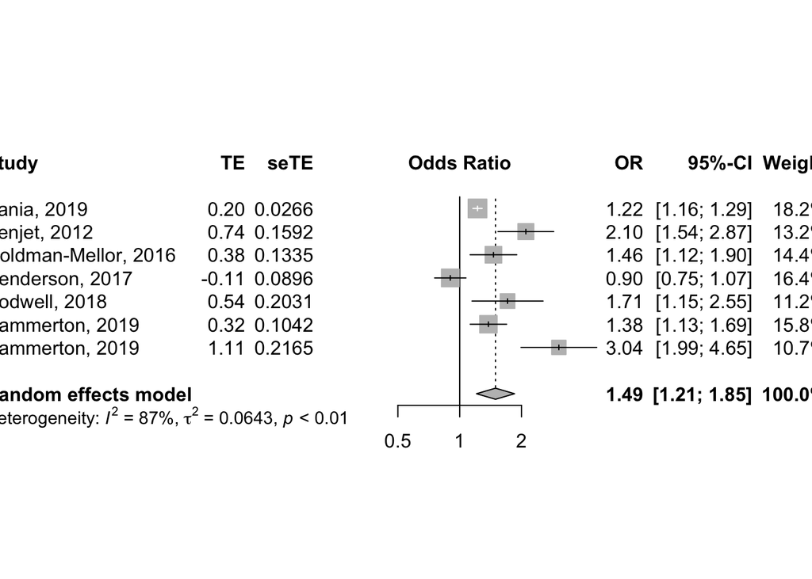

```r
forest(meta.MHbeh.Gall.rep0)
```

### BEHAVIOURAL - directionality

# `{r} # MHbeh.Gall.rep1 <- neet2[which(neet2$Behavioral==1 & neet2$Gender=="all"),] # # MHbeh.Gall.rep1 # # meta.MHbeh.Gall.rep1 <- metagen(OR_ln, # SE, # data=MHbeh.Gall.rep1, # studlab=paste(Study), # comb.fixed = FALSE, # comb.random = TRUE, # method.tau = "DL", # hakn = FALSE, # prediction=FALSE, # sm="OR") # meta.MHbeh.Gall.rep1 # # meta.MHbeh.Gall.rep1.dir<-update.meta(meta.MHbeh.Gall.rep1, # byvar=Temporality.of.measures, # comb.random = F, # comb.fixed = T) # meta.MHbeh.Gall.rep1.dir # # forest(meta.MHbeh.Gall.rep1.dir) #`

### BEHAVIOURAL - age

# `{r} # # MHbeh.Gall.rep0.age <- neet3[which(neet3$Behavioral==1 & neet3$Gender=="all" & is.na(neet3$Repeated_sample)),] # # MHbeh.Gall.rep0.age # # MHbeh.Gall.rep0.age <- bind_rows(MHbeh.Gall.rep0.age, neet3[which(neet3$study_no=="gutierrez 2019 3"),]) # # MHbeh.Gall.rep0.age # # # meta.MHbeh.Gall.rep0.age <- metagen(OR_ln, # SE, # data=MHbeh.Gall.rep0.age, # studlab=paste(Study), # comb.fixed = FALSE, # comb.random = TRUE, # method.tau = "DL", # hakn = FALSE, # prediction=FALSE, # sm="OR") # meta.MHbeh.Gall.rep0.age # # meta.MHbeh.Gall.rep0.age.dir<-update.meta(meta.MHbeh.Gall.rep0.age, # byvar=Age_at_interview, # comb.random = F, # comb.fixed = T) # meta.MHbeh.Gall.rep0.age.dir # # # forest(meta.MHbeh.Gall.rep0.age.dir) #`

### BEHAVIOURAL - gender

# `{r} # MHbeh.Gbg.rep0 <- neet2[which(neet2$Behavioral==1 & neet2$Gender!="all" & is.na(neet2$Repeated_sample)),] # # MHbeh.Gbg.rep0 # # meta.MHbeh.Gbg.rep0 <- metagen(OR_ln, # SE, # data=MHbeh.Gbg.rep0, # studlab=paste(Study), # comb.fixed = FALSE, # comb.random = TRUE, # method.tau = "DL", # hakn = FALSE, # prediction=FALSE, # sm="OR") # meta.MHbeh.Gbg.rep0 # # # meta.MHbeh.Gbg.rep0<-update.meta(meta.MHbeh.Gbg.rep0, # byvar=Gender, # comb.random = F, # comb.fixed = T) # meta.MHbeh.Gbg.rep0 # # forest(meta.MHbeh.Gbg.rep0) #`

## ALCOHOL

alcohol = 1, gender = all, repeated sample = 0

```r
MHalc.Gall.rep0 <- filter(neet, Alcohol==1 & Gender=="all" & is.na(Repeated_sample))

MHalc.Gall.rep0
```

| X | Study | Country | study_no | Mental.health.measures | Temporality.of.measures | Results | Repeated_sample | MH_measure | MH.measure.included | Gender | Age_at_interview | OR | LowerCI | UpperCI | OR_ln | lower_ln | upper_ln | SE | LowerCI_sens | UpperCI_sens | Distress | Mood | Anxiety | Behavioral | Alcohol | Cannabis | Drug | Suicidal | Any | … |
| --- | --- | --- | --- | --- | --- | --- | --- | --- | --- | --- | --- | --- | --- | --- | --- | --- | --- | --- | --- | --- | --- | --- | --- | --- | --- | --- | --- | --- | --- | --- |
| 4 | Baggio, 2015 | Switzerland | baggio 2015 3 | Binge drinking | MH-->NEET | OR NA, P>0.05 | NA | alcohol | NA | all | >=18 | NA | NA | NA | NA | NA | NA | NA | NA | NA | 0 | 0 | 0 | 0 | 1 | 0 | 0 | 0 | 0 | … |
| 39 | Gariepy, 2018 | Canada | gariepy 2018 4 | Alcohol use disorder | MHNEET | OR 1.0, 95% CI 0.6, 1.7 | NA | alcohol | NA | all | NA | 1.00 | 0.60 | 1.70 | 0.0000000 | -0.510825624 | 0.5306283 | 0.26567701 | NA | NA | 0 | 0 | 0 | 0 | 1 | 0 | 0 | 0 | 0 | … |
| 46 | Goldman-Mellor, 2016 | UK | goldman 2016 3 | Alcohol dependence | MHNEET | OR 1.42, 95% CI 1.01, 2.01 | NA | alcohol | NA | all | >=18 | 1.42 | 1.01 | 2.01 | 0.3506569 | 0.009950331 | 0.6981347 | 0.17555724 | NA | NA | 0 | 0 | 0 | 0 | 1 | 0 | 0 | 0 | 0 | … |
| 67 | Gutierrez-Garcia, 2019 | Mexico | gutierrez 2019 4 | Alcohol use disorder | MHNEET | OR 1.38, 95% CI 1.02, 1.45 | NA | alcohol | NA | all | >=18 | 1.38 | 1.02 | 1.45 | 0.3220835 | 0.019802627 | 0.3715636 | 0.08973493 | NA | NA | 0 | 0 | 0 | 0 | 1 | 0 | 0 | 0 | 0 | … |
| 102 | O'Dea, 2014 | Australia | odea 2014 3 | Alcohol use disorder | MHNEET | OR NA, P>0.05 | NA | alcohol | NA | all | NA | NA | NA | NA | NA | NA | NA | NA | NA | NA | 0 | 0 | 0 | 0 | 1 | 0 | 0 | 0 | 0 | … |
| 107 | Power, 2015 | Ireland | power 2015 3 | Alcohol use disorder (lifetime) | MHNEET | OR NA, P>0.05 | NA | alcohol | NA | all | >=18 | NA | NA | NA | NA | NA | NA | NA | NA | NA | 0 | 0 | 0 | 0 | 1 | 0 | 0 | 0 | 0 | … |
| 120 | Rodwell, 2018 | Australia | rodwell 2018 4 | Heavy binger drinking | MH-->NEET | OR 0.80, 95% CI 0.48, 1.34 | NA | alcohol | NA | all | >=18 | 0.80 | 0.48 | 1.34 | -0.2231436 | -0.733969175 | 0.2926696 | 0.26189765 | NA | NA | 0 | 0 | 0 | 0 | 1 | 0 | 0 | 0 | 0 | … |
| 124 | Manhica, 2019 | Sweden | Manhica 2019 1 | Alcohol use disorder | NEET-->MH | HR 1.30, 95% CI 1.11, 1.51 | NA | alcohol | NA | all | NA | 1.30 | 1.11 | 1.51 | 0.2623643 | 0.104360015 | 0.4121097 | 0.07850756 | NA | NA | 0 | 0 | 0 | 0 | 1 | 0 | 0 | 0 | 0 | … |

```r
meta.MHalc.Gall.rep0 <- metagen(OR_ln,
                                SE,
                                data=MHalc.Gall.rep0,
                                studlab=paste(Study),
                                comb.fixed = FALSE,
                                comb.random = TRUE,
                                method.tau = "DL",
                                hakn = FALSE,
                                prediction=FALSE,
                                sm="OR")
meta.MHalc.Gall.rep0
```

```
##                            OR           95%-CI %W(random)
## Baggio, 2015               NA                         0.0
## Gariepy, 2018          1.0000 [0.5941; 1.6832]        6.0
## Goldman-Mellor, 2016   1.4200 [1.0066; 2.0032]       12.6
## Gutierrez-Garcia, 2019 1.3800 [1.1574; 1.6454]       34.7
## O'Dea, 2014                NA                         0.0
## Power, 2015                NA                         0.0
## Rodwell, 2018          0.8000 [0.4788; 1.3366]        6.1
## Manhica, 2019          1.3000 [1.1146; 1.5162]       40.6
##
## Number of studies combined: k = 5
##
##                          OR           95%-CI    z p-value
## Random effects model 1.2824 [1.1242; 1.4629] 3.70  0.0002
##
## Quantifying heterogeneity:
##  tau^2 = 0.0050 [0.0000; 0.3452]; tau = 0.0704 [0.0000; 0.5875];
##  I^2 = 21.7% [0.0%; 67.2%]; H = 1.13 [1.00; 1.75]
##
## Test of heterogeneity:
##     Q d.f. p-value
##  5.11    4  0.2765
##
## Details on meta-analytical method:
## - Inverse variance method
## - DerSimonian-Laird estimator for tau^2
## - Jackson method for confidence interval of tau^2 and tau
```

### ALCOHOL - directionality

# `{r} # # MHalc.Gall.rep1 <- neet2[which(neet2$Alcohol==1 & neet2$Gender=="all"),] # # head(MHalc.Gall.rep1) # # meta.MHalc.Gall.rep1 <- metagen(OR_ln, # SE, # data=MHalc.Gall.rep1, # studlab=paste(Study), # comb.fixed = FALSE, # comb.random = TRUE, # method.tau = "DL", # hakn = FALSE, # prediction=FALSE, # sm="OR") # meta.MHalc.Gall.rep1 # # meta.MHalc.Gall.rep1.dir<-update.meta(meta.MHalc.Gall.rep1, # byvar=Temporality.of.measures, # comb.random = F, # comb.fixed = T) # meta.MHalc.Gall.rep1.dir # # forest(meta.MHalc.Gall.rep1.dir) #`

### ALCOHOL - age

# `{r} # # MHalc.Gall.rep0.age <- neet3[which(neet3$Alcohol==1 & neet3$Gender=="all" & is.na(neet3$Repeated_sample)),] # # MHalc.Gall.rep0.age # # MHalc.Gall.rep0.age <- bind_rows(MHalc.Gall.rep0.age, neet3[which(neet3$study_no=="gutierrez 2019 4"),]) # # MHalc.Gall.rep0.age # # # meta.MHalc.Gall.rep0.age <- metagen(OR_ln, # SE, # data=MHalc.Gall.rep0.age, # studlab=paste(Study), # comb.fixed = FALSE, # comb.random = TRUE, # method.tau = "DL", # hakn = FALSE, # prediction=FALSE, # sm="OR") # meta.MHalc.Gall.rep0.age # # meta.MHalc.Gall.rep0.age.dir<-update.meta(meta.MHalc.Gall.rep0.age, # byvar=Age_at_interview, # comb.random = F, # comb.fixed = T) # meta.MHalc.Gall.rep0.age.dir # # # forest(meta.MHalc.Gall.rep0.age.dir) #`

### ALCOHOL - gender

# `{r} # MHalc.Gbg.rep0 <- neet2[which(neet2$Alcohol==1 & neet2$Gender!="all" & is.na(neet2$Repeated_sample)),] # # head(MHalc.Gbg.rep0) #`

## CANNABIS

cannabis = 1, gender = all, repeated sample = 0

```r
MHcan.Gall.rep0 <- filter(neet, Cannabis==1 & Gender=="all" & is.na(Repeated_sample))

MHcan.Gall.rep0
```

| X | Study | Country | study_no | Mental.health.measures | Temporality.of.measures | Results | Repeated_sample | MH_measure | MH.measure.included | Gender | Age_at_interview | OR | LowerCI | UpperCI | OR_ln | lower_ln | upper_ln | SE | LowerCI_sens | UpperCI_sens | Distress | Mood | Anxiety | Behavioral | Alcohol | Cannabis | Drug | Suicidal | Any | … |
| --- | --- | --- | --- | --- | --- | --- | --- | --- | --- | --- | --- | --- | --- | --- | --- | --- | --- | --- | --- | --- | --- | --- | --- | --- | --- | --- | --- | --- | --- | --- |
| 5 | Baggio, 2015 | Switzerland | baggio 2015 4 | Cannabis use disorder | MH-->NEET | OR 1.09, P<0.001 | NA | cannabis | NA | all | >=18 | 1.09 | 1.04 | 1.15 | 0.0861777 | 0.03922071 | 0.1397619 | 0.02564827 | NA | NA | 0 | 0 | 0 | 0 | 0 | 1 | 0 | 0 | 0 | … |
| 40 | Gariepy, 2018 | Canada | gariepy 2018 5 | Cannabis disorder | MHNEET | OR 1.0, 95% CI 0.5, 2.0 | NA | cannabis | NA | all | NA | 1.00 | 0.50 | 2.00 | 0.0000000 | -0.69314718 | 0.6931472 | 0.35364652 | NA | NA | 0 | 0 | 0 | 0 | 0 | 1 | 0 | 0 | 0 | … |
| 47 | Goldman-Mellor, 2016 | UK | goldman 2016 4 | Cannabis dependence | MHNEET | OR 3.93, 95% CI 2.31, 6.68 | NA | cannabis | NA | all | >=18 | 3.93 | 2.31 | 6.68 | 1.3686394 | 0.83724752 | 1.8991180 | 0.27088532 | NA | NA | 0 | 0 | 0 | 0 | 0 | 1 | 0 | 0 | 0 | … |
| 103 | O'Dea, 2014 | Australia | odea 2014 4 | Cannabis use disorder | MHNEET | OR 1.22, 95% CI 0.72, 2.05 | NA | cannabis | NA | all | NA | 1.22 | 0.72 | 2.05 | 0.1988509 | -0.32850407 | 0.7178398 | 0.26692445 | NA | NA | 0 | 0 | 0 | 0 | 0 | 1 | 0 | 0 | 0 | … |
| 119 | Rodwell, 2018 | Australia | rodwell 2018 3 | Cannabis use disorder | MH-->NEET | OR 1.74, 95% CI 1.10, 2.75 | NA | cannabis | NA | all | >=18 | 1.74 | 1.10 | 2.75 | 0.5538851 | 0.09531018 | 1.0116009 | 0.23374764 | NA | NA | 0 | 0 | 0 | 0 | 0 | 1 | 0 | 0 | 0 | … |
| 127 | Stea, 2019b | Sweden | Stea 2019b 1 | Cannabis use | MHNEET | OR 2.20, 95% CI 1.10, 4.30 | NA | cannabis | NA | all | NA | 2.20 | 1.10 | 4.30 | 0.7884574 | 0.09531018 | 1.4586150 | 0.34778185 | NA | NA | 0 | 0 | 0 | 0 | 0 | 1 | 0 | 0 | 0 | … |

```r
meta.MHcan.Gall.rep0 <- metagen(OR_ln,
                                SE,
                                data=MHcan.Gall.rep0,
                                studlab=paste(Study),
                                comb.fixed = FALSE,
                                comb.random = TRUE,
                                method.tau = "DL",
                                hakn = FALSE,
                                prediction=FALSE,
                                sm="OR")
meta.MHcan.Gall.rep0
```

```
##                          OR           95%-CI %W(random)
## Baggio, 2015         1.0900 [1.0366; 1.1462]       22.0
## Gariepy, 2018        1.0000 [0.5000; 2.0000]       13.8
## Goldman-Mellor, 2016 3.9300 [2.3111; 6.6830]       16.3
## O'Dea, 2014          1.2200 [0.7230; 2.0586]       16.4
## Rodwell, 2018        1.7400 [1.1005; 2.7512]       17.5
## Stea, 2019b          2.2000 [1.1127; 4.3497]       13.9
##
## Number of studies combined: k = 6
##
##                          OR           95%-CI    z p-value
## Random effects model 1.6189 [1.0652; 2.4606] 2.26  0.0241
##
## Quantifying heterogeneity:
##  tau^2 = 0.2063 [0.0446; 1.7590]; tau = 0.4542 [0.2113; 1.3263];
##  I^2 = 83.4% [65.1%; 92.1%]; H = 2.45 [1.69; 3.55]
##
## Test of heterogeneity:
##      Q d.f.  p-value
##  30.06    5 < 0.0001
##
## Details on meta-analytical method:
## - Inverse variance method
## - DerSimonian-Laird estimator for tau^2
## - Jackson method for confidence interval of tau^2 and tau
```

### CANNABIS - directionality

# `{r} # meta.MHcan.Gall.rep0.dir<-update.meta(meta.MHcan.Gall.rep0, # byvar=Temporality.of.measures, # comb.random = F, # comb.fixed = T) # meta.MHcan.Gall.rep0.dir # # forest(meta.MHcan.Gall.rep0.dir) #`

### CANNABIS - age

# `{r} # # MHcan.Gall.rep1.age <- neet3[which(neet3$Cannabis==1 & neet3$Gender=="all"),] # # head(MHcan.Gall.rep1.age) # # # meta.MHcan.Gall.rep1.age <- metagen(OR_ln, # SE, # data=MHcan.Gall.rep1.age, # studlab=paste(Study), # comb.fixed = FALSE, # comb.random = TRUE, # method.tau = "DL", # hakn = FALSE, # prediction=FALSE, # sm="OR") # meta.MHcan.Gall.rep1.age # # meta.MHcan.Gall.rep1.age.dir<-update.meta(meta.MHcan.Gall.rep1.age, # byvar=Age_at_interview, # comb.random = F, # comb.fixed = T) # meta.MHcan.Gall.rep1.age.dir # # # forest(meta.MHcan.Gall.rep1.age.dir) #`

### CANNABIS - gender

# `{r} # MHcan.Gbg.rep0 <- neet2[which(neet2$Cannabis==1 & neet2$Gender!="all" & is.na(neet2$Repeated_sample)),] # # head(MHcan.Gbg.rep0) #`

## DRUG

drug = 1, gender = all, repeated sample = 0

# `{r} # MHdrg.Gall.rep0 <- neet2[which(neet2$Drug==1 & neet2$Gender=="all" & is.na(neet2$Repeated_sample)),] # # head(MHdrg.Gall.rep0) # # meta.MHdrg.Gall.rep0 <- metagen(OR_ln, # SE, # data=MHdrg.Gall.rep0, # studlab=paste(Study), # comb.fixed = FALSE, # comb.random = TRUE, # method.tau = "DL", # hakn = FALSE, # prediction=FALSE, # sm="OR") # meta.MHdrg.Gall.rep0 #`

### DRUG - directionality

# `{r} # MHdrg.Gall.rep1 <- neet2[which(neet2$Drug==1 & neet2$Gender=="all"),] # # head(MHdrg.Gall.rep1) # # meta.MHdrg.Gall.rep1 <- metagen(OR_ln, # SE, # data=MHdrg.Gall.rep1, # studlab=paste(Study), # comb.fixed = FALSE, # comb.random = TRUE, # method.tau = "DL", # hakn = FALSE, # prediction=FALSE, # sm="OR") # meta.MHdrg.Gall.rep1 # # meta.MHdrg.Gall.rep1.dir<-update.meta(meta.MHdrg.Gall.rep1, # byvar=Temporality.of.measures, # comb.random = F, # comb.fixed = T) # meta.MHdrg.Gall.rep1.dir # # forest(meta.MHdrg.Gall.rep1.dir) #`

### DRUG - age

# `{r} # # MHdrg.Gall.rep0.age <- neet3[which(neet3$Drug==1 & neet3$Gender=="all" & is.na(neet3$Repeated_sample)),] # # MHdrg.Gall.rep0.age # # MHdrg.Gall.rep0.age <- bind_rows(MHdrg.Gall.rep0.age, neet3[which(neet3$study_no=="gutierrez 2019 6"),]) # # MHdrg.Gall.rep0.age # # # meta.MHdrg.Gall.rep0.age <- metagen(OR_ln, # SE, # data=MHdrg.Gall.rep0.age, # studlab=paste(Study), # comb.fixed = FALSE, # comb.random = TRUE, # method.tau = "DL", # hakn = FALSE, # prediction=FALSE, # sm="OR") # meta.MHdrg.Gall.rep0.age # # meta.MHdrg.Gall.rep0.age.dir<-update.meta(meta.MHdrg.Gall.rep0.age, # byvar=Age_at_interview, # comb.random = F, # comb.fixed = T) # meta.MHdrg.Gall.rep0.age.dir # # # forest(meta.MHdrg.Gall.rep0.age.dir) #`

### DRUG - gender

# `{r} # MHdrg.Gbg.rep0 <- neet2[which(neet2$Drug==1 & neet2$Gender!="all" & is.na(neet2$Repeated_sample)),] # # head(MHdrg.Gbg.rep0) # # meta.MHdrg.Gbg.rep0 <- metagen(OR_ln, # SE, # data=MHdrg.Gbg.rep0, # studlab=paste(Study), # comb.fixed = FALSE, # comb.random = TRUE, # method.tau = "DL", # hakn = FALSE, # prediction=FALSE, # sm="OR") # meta.MHdrg.Gbg.rep0 # # # meta.MHdrg.Gbg.rep0<-update.meta(meta.MHdrg.Gbg.rep0, # byvar=Gender, # comb.random = F, # comb.fixed = T) # meta.MHdrg.Gbg.rep0 # # forest(meta.MHdrg.Gbg.rep0) #`

## SUICIDAL

suicidal = 1, gender = all, repeated sample = 0

# `{r} # MHsui.Gall.rep0 <- neet2[which(neet2$Suicidal==1 & neet2$Gender=="all" & is.na(neet2$Repeated_sample)),] # # head(MHsui.Gall.rep0) # # meta.MHsui.Gall.rep0 <- metagen(OR_ln, # SE, # data=MHsui.Gall.rep0, # studlab=paste(Study), # comb.fixed = FALSE, # comb.random = TRUE, # method.tau = "DL", # hakn = FALSE, # prediction=FALSE, # sm="OR") # meta.MHsui.Gall.rep0 #`

### SUICIDAL - directionality

# `{r} # MHsui.Gall.rep1 <- neet2[which(neet2$Suicidal==1 & neet2$Gender=="all"),] # # head(MHsui.Gall.rep1) # # meta.MHsui.Gall.rep1 <- metagen(OR_ln, # SE, # data=MHsui.Gall.rep1, # studlab=paste(Study), # comb.fixed = FALSE, # comb.random = TRUE, # method.tau = "DL", # hakn = FALSE, # prediction=FALSE, # sm="OR") # meta.MHsui.Gall.rep1 # # meta.MHsui.Gall.rep1.dir<-update.meta(meta.MHsui.Gall.rep1, # byvar=Temporality.of.measures, # comb.random = F, # comb.fixed = T) # meta.MHsui.Gall.rep1.dir # # forest(meta.MHsui.Gall.rep1.dir) #`

### SUICIDAL - age

# `{r} # # MHsui.Gall.rep0.age <- neet3[which(neet3$Suicidal==1 & neet3$Gender=="all" & is.na(neet3$Repeated_sample)),] # # MHsui.Gall.rep0.age # # MHsui.Gall.rep0.age <- bind_rows(MHsui.Gall.rep0.age, neet3[which(neet3$study_no=="gutierrez 2019 9"),]) # # MHsui.Gall.rep0.age # # # meta.MHsui.Gall.rep0.age <- metagen(OR_ln, # SE, # data=MHsui.Gall.rep0.age, # studlab=paste(Study), # comb.fixed = FALSE, # comb.random = TRUE, # method.tau = "DL", # hakn = FALSE, # prediction=FALSE, # sm="OR") # meta.MHsui.Gall.rep0.age # # meta.MHsui.Gall.rep0.age.dir<-update.meta(meta.MHsui.Gall.rep0.age, # byvar=Age_at_interview, # comb.random = F, # comb.fixed = T) # meta.MHsui.Gall.rep0.age.dir # # # forest(meta.MHsui.Gall.rep0.age.dir) #`

# `{r} # # MHsuiatt <- neet3[c(63,95),] # # MHsuiatt # # meta.MHsuiatt <- metagen(OR_ln, # SE, # data=MHsuiatt, # studlab=paste(Study), # comb.fixed = T, # comb.random = F, # method.tau = "DL", # hakn = FALSE, # prediction=FALSE, # sm="OR") # meta.MHsuiatt # # forest(meta.MHsuiatt) # #`

### SUICIDAL - gender

# `{r} # MHsui.Gbg.rep0 <- neet2[which(neet2$Suicidal==1 & neet2$Gender!="all" & is.na(neet2$Repeated_sample)),] # # head(MHsui.Gbg.rep0) #`

## ANY

any = 1, gender = all, repeated sample = 0

# `{r} # MHany.Gall.rep0 <- neet2[which(neet2$Any==1 & neet2$Gender=="all" & is.na(neet2$Repeated_sample)),] # # head(MHany.Gall.rep0) #`

Gen says to only use Power 2015’s “Any lifetime disorder” here and “Any dx in adol” for directionality

# `{r} # MHany.Gall.rep0 <- MHany.Gall.rep0[c(1,2,4),] # # head(MHany.Gall.rep0) # # meta.MHany.Gall.rep0 <- metagen(OR_ln, # SE, # data=MHany.Gall.rep0, # studlab=paste(Study), # comb.fixed = FALSE, # comb.random = TRUE, # method.tau = "DL", # hakn = FALSE, # prediction=FALSE, # sm="OR") # meta.MHany.Gall.rep0 #`

### ANY - directionality

# `{r} # MHany.Gall.rep0 <- neet2[which(neet2$Any==1 & neet2$Gender=="all" & is.na(neet2$Repeated_sample)),] # # head(MHany.Gall.rep0) #`

Gen says to only use Power 2015’s “Any dx in adol” for directionality # `{r} # MHany.Gall.rep0 <- MHany.Gall.rep0[c(1,3,4),] # # head(MHany.Gall.rep0) # # meta.MHany.Gall.rep0 <- metagen(OR_ln, # SE, # data=MHany.Gall.rep0, # studlab=paste(Study), # comb.fixed = FALSE, # comb.random = TRUE, # method.tau = "DL", # hakn = FALSE, # prediction=FALSE, # sm="OR") # meta.MHany.Gall.rep0 # # # meta.MHany.Gall.rep0.dir<-update.meta(meta.MHany.Gall.rep0, # byvar=Temporality.of.measures, # comb.random = F, # comb.fixed = T) # meta.MHany.Gall.rep0.dir # # forest(meta.MHany.Gall.rep0.dir) #`

### ANY - age

makes sense to use “any lifetime disorder” (the more comprehensive measure) for this analysis # `{r} # # MHany.Gall.rep1.age <- neet3[which(neet3$Any==1 & neet3$Gender=="all"),] # # MHany.Gall.rep1.age <- MHany.Gall.rep1.age[c(1,2,4),] # # head(MHany.Gall.rep1.age) # # # meta.MHany.Gall.rep1.age <- metagen(OR_ln, # SE, # data=MHany.Gall.rep1.age, # studlab=paste(Study), # comb.fixed = FALSE, # comb.random = TRUE, # method.tau = "DL", # hakn = FALSE, # prediction=FALSE, # sm="OR") # meta.MHany.Gall.rep1.age # # meta.MHany.Gall.rep1.age.dir<-update.meta(meta.MHany.Gall.rep1.age, # byvar=Age_at_interview, # comb.random = F, # comb.fixed = T) # meta.MHany.Gall.rep1.age.dir # # # forest(meta.MHany.Gall.rep1.age.dir) #`

### ANY - gender

# `{r} # MHany.Gbg.rep0 <- neet2[which(neet2$Any==1 & neet2$Gender!="all" & is.na(neet2$Repeated_sample)),] # # head(MHany.Gbg.rep0) #`